# Imager Tutorial

# Before Loading *imager*

## XQuartz

If you are using a mac, you must install XQuartz before loading imager. It is a download that was created by Apple as “a community effort to fruther develop and support X11 on Mac”, something which is no longer included with Macs (Online Apple Support). XQuartz can be downloaded [here](https://www.xquartz.org).

# Using *imager*

## Loading *imager*

Once XQuartz is downloaded the package must be installed from CRAN. Once in, you can call it using the library call.

```r
library(imager)
```

## Pre-loaded images

Imager has a pre-loaded image called “boats”. You can use this image to investigate a number of interesting features of imager. Firstly, in order to view the image as an image you must use the plot call.

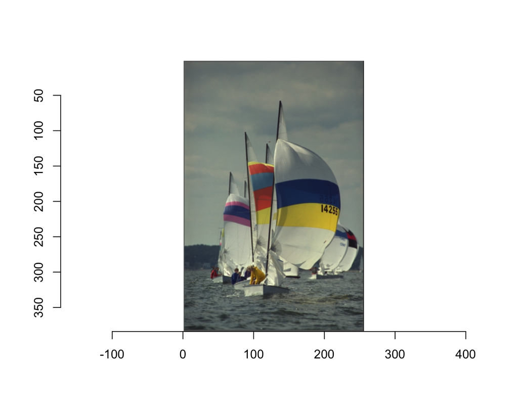

```r
plot(boats)
```

The image is only displayed as an picture using the plot call because on the back end of R Studio, the image is saved as an array of numbers, called an imager-array. You can get some basic information about the image by simply calling the image. However, as you see this does not result in a picture being displayed.

```r
boats
```

```
## Image. Width: 256 pix Height: 384 pix Depth: 1 Colour channels: 3
```

You are given the dimentions of the image, in pixels as well as well as the depth and the number of color channels. When the depth is over 1, there are multiple frames and it is actually a movie.

## *Imager* Math

Because the images are stored as numbers, you can do math with the values themselves. For example, you can find the mean of the image “boats”.

```r
mean(boats)
```

```
## [1] 0.5089061
```

Though the value of 0.5089061 is not able to be visualized using imager, you can see the results of math on images using specific calls.

You can divide “boats” by 2. In order to view both the original image as well as the edited image we have to add a few calls. First, we must change the layout so we can see both images in the same frame. Additionally, the plot call automatically recales images to originial size and color. In order to stop this and be able to see the difference between the two images you must set rescale=FALSE.

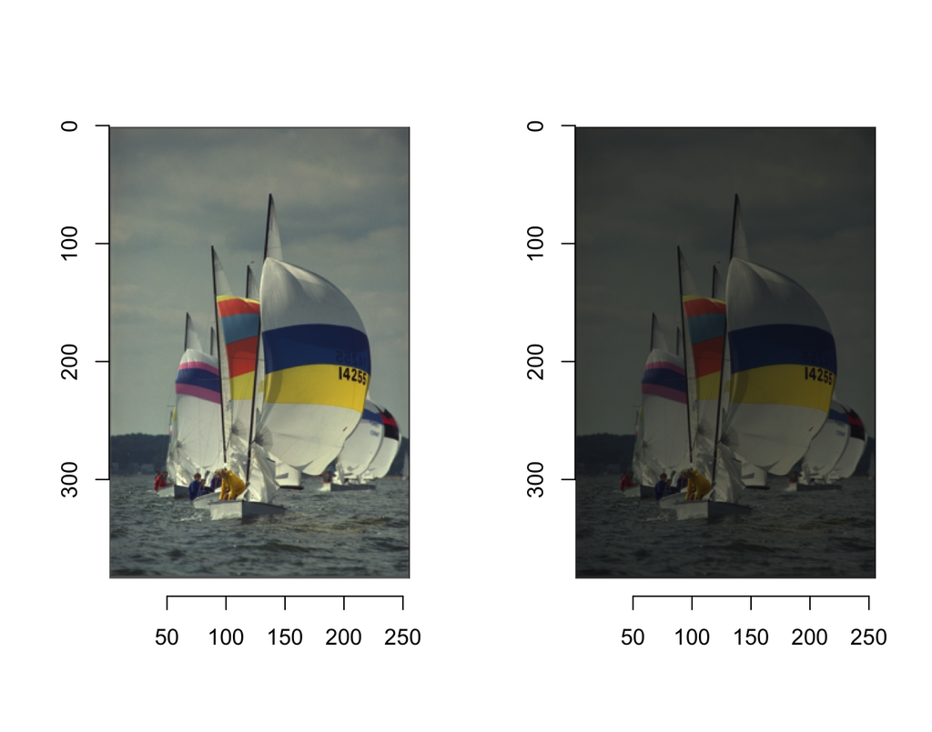

```r
layout(t(1:2))
plot(boats,rescale=FALSE)
plot(boats/2,rescale=FALSE)
```

## Changing the color scheme of an image

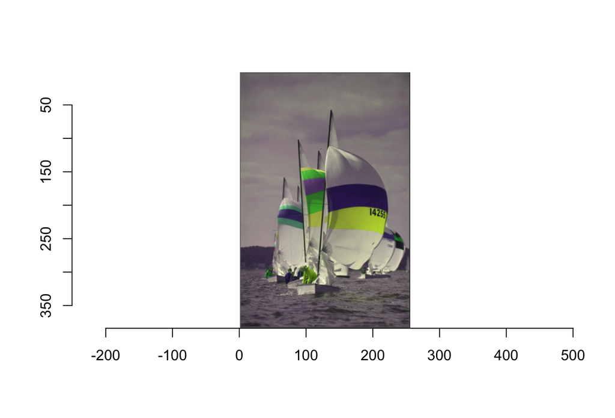

```r
cscale <- function(r,g,b) rgb(g,r,b)
plot(boats,colourscale=cscale,rescale=FALSE)
```